# Risk Factor Analysis

## Outcome Variable

**Outcome Variable:** whz

## Predictor Variables

**Intervention Variable:** nhh

**Adjustment Set:**

- arm
- W_mage
- meducyrs
- feducyrs
- hhwealth_quart
- W_mhtcm
- W_mwtkg
- W_mbmi
- W_nrooms
- cleanck
- impfloor
- impsan
- safeh20
- delta_W_mage
- delta_meducyrs
- delta_feducyrs
- delta_hhwealth_quart
- delta_W_mhtcm
- delta_W_mwtkg
- delta_W_mbmi
- delta_W_nrooms
- delta_cleanck
- delta_impfloor
- delta_impsan
- delta_safeh20

## Stratifying Variables

The analysis was stratified on these variable(s):

- agecat
- studyid
- country

## Data Summary

| agecat | studyid | country | nhh | n_cell | n |
| --- | --- | --- | --- | --- | --- |
| Birth | ki1000108-IRC | INDIA | 3 or less | 52 | 343 |
| Birth | ki1000108-IRC | INDIA | 4-5 | 131 | 343 |
| Birth | ki1000108-IRC | INDIA | 6-7 | 84 | 343 |
| Birth | ki1000108-IRC | INDIA | 8+ | 76 | 343 |
| Birth | ki1017093-NIH-Birth | BANGLADESH | 3 or less | 7 | 28 |
| Birth | ki1017093-NIH-Birth | BANGLADESH | 4-5 | 11 | 28 |
| Birth | ki1017093-NIH-Birth | BANGLADESH | 6-7 | 7 | 28 |
| Birth | ki1017093-NIH-Birth | BANGLADESH | 8+ | 3 | 28 |
| Birth | ki1017093c-NIH-Crypto | BANGLADESH | 3 or less | 8 | 23 |
| Birth | ki1017093c-NIH-Crypto | BANGLADESH | 4-5 | 7 | 23 |
| Birth | ki1017093c-NIH-Crypto | BANGLADESH | 6-7 | 5 | 23 |
| Birth | ki1017093c-NIH-Crypto | BANGLADESH | 8+ | 3 | 23 |
| 6 months | ki1000108-IRC | INDIA | 3 or less | 57 | 408 |
| 6 months | ki1000108-IRC | INDIA | 4-5 | 157 | 408 |
| 6 months | ki1000108-IRC | INDIA | 6-7 | 107 | 408 |
| 6 months | ki1000108-IRC | INDIA | 8+ | 87 | 408 |
| 6 months | ki1000304b-SAS-FoodSuppl | INDIA | 3 or less | 33 | 380 |
| 6 months | ki1000304b-SAS-FoodSuppl | INDIA | 4-5 | 166 | 380 |
| 6 months | ki1000304b-SAS-FoodSuppl | INDIA | 6-7 | 115 | 380 |
| 6 months | ki1000304b-SAS-FoodSuppl | INDIA | 8+ | 66 | 380 |
| 6 months | ki1017093-NIH-Birth | BANGLADESH | 3 or less | 95 | 536 |
| 6 months | ki1017093-NIH-Birth | BANGLADESH | 4-5 | 227 | 536 |
| 6 months | ki1017093-NIH-Birth | BANGLADESH | 6-7 | 127 | 536 |
| 6 months | ki1017093-NIH-Birth | BANGLADESH | 8+ | 87 | 536 |
| 6 months | ki1017093b-PROVIDE | BANGLADESH | 3 or less | 102 | 582 |
| 6 months | ki1017093b-PROVIDE | BANGLADESH | 4-5 | 277 | 582 |
| 6 months | ki1017093b-PROVIDE | BANGLADESH | 6-7 | 126 | 582 |
| 6 months | ki1017093b-PROVIDE | BANGLADESH | 8+ | 77 | 582 |
| 6 months | ki1017093c-NIH-Crypto | BANGLADESH | 3 or less | 104 | 715 |
| 6 months | ki1017093c-NIH-Crypto | BANGLADESH | 4-5 | 326 | 715 |
| 6 months | ki1017093c-NIH-Crypto | BANGLADESH | 6-7 | 170 | 715 |
| 6 months | ki1017093c-NIH-Crypto | BANGLADESH | 8+ | 115 | 715 |
| 6 months | ki1148112-LCNI-5 | MALAWI | 3 or less | 224 | 816 |
| 6 months | ki1148112-LCNI-5 | MALAWI | 4-5 | 340 | 816 |
| 6 months | ki1148112-LCNI-5 | MALAWI | 6-7 | 182 | 816 |
| 6 months | ki1148112-LCNI-5 | MALAWI | 8+ | 70 | 816 |
| 24 months | ki1000108-IRC | INDIA | 3 or less | 58 | 409 |
| 24 months | ki1000108-IRC | INDIA | 4-5 | 158 | 409 |
| 24 months | ki1000108-IRC | INDIA | 6-7 | 107 | 409 |
| 24 months | ki1000108-IRC | INDIA | 8+ | 86 | 409 |
| 24 months | ki1017093-NIH-Birth | BANGLADESH | 3 or less | 74 | 428 |
| 24 months | ki1017093-NIH-Birth | BANGLADESH | 4-5 | 184 | 428 |
| 24 months | ki1017093-NIH-Birth | BANGLADESH | 6-7 | 100 | 428 |
| 24 months | ki1017093-NIH-Birth | BANGLADESH | 8+ | 70 | 428 |
| 24 months | ki1017093b-PROVIDE | BANGLADESH | 3 or less | 105 | 578 |
| 24 months | ki1017093b-PROVIDE | BANGLADESH | 4-5 | 273 | 578 |
| 24 months | ki1017093b-PROVIDE | BANGLADESH | 6-7 | 117 | 578 |
| 24 months | ki1017093b-PROVIDE | BANGLADESH | 8+ | 83 | 578 |
| 24 months | ki1017093c-NIH-Crypto | BANGLADESH | 3 or less | 69 | 514 |
| 24 months | ki1017093c-NIH-Crypto | BANGLADESH | 4-5 | 232 | 514 |
| 24 months | ki1017093c-NIH-Crypto | BANGLADESH | 6-7 | 130 | 514 |
| 24 months | ki1017093c-NIH-Crypto | BANGLADESH | 8+ | 83 | 514 |
| 24 months | ki1148112-LCNI-5 | MALAWI | 3 or less | 157 | 558 |
| 24 months | ki1148112-LCNI-5 | MALAWI | 4-5 | 230 | 558 |
| 24 months | ki1148112-LCNI-5 | MALAWI | 6-7 | 123 | 558 |
| 24 months | ki1148112-LCNI-5 | MALAWI | 8+ | 48 | 558 |

The following strata were considered:

- agecat: 24 months, studyid: ki1000108-IRC, country: INDIA
- agecat: 24 months, studyid: ki1017093-NIH-Birth, country: BANGLADESH
- agecat: 24 months, studyid: ki1017093b-PROVIDE, country: BANGLADESH
- agecat: 24 months, studyid: ki1017093c-NIH-Crypto, country: BANGLADESH
- agecat: 24 months, studyid: ki1148112-LCNI-5, country: MALAWI
- agecat: 6 months, studyid: ki1000108-IRC, country: INDIA
- agecat: 6 months, studyid: ki1000304b-SAS-FoodSuppl, country: INDIA
- agecat: 6 months, studyid: ki1017093-NIH-Birth, country: BANGLADESH
- agecat: 6 months, studyid: ki1017093b-PROVIDE, country: BANGLADESH
- agecat: 6 months, studyid: ki1017093c-NIH-Crypto, country: BANGLADESH
- agecat: 6 months, studyid: ki1148112-LCNI-5, country: MALAWI
- agecat: Birth, studyid: ki1000108-IRC, country: INDIA
- agecat: Birth, studyid: ki1017093-NIH-Birth, country: BANGLADESH
- agecat: Birth, studyid: ki1017093c-NIH-Crypto, country: BANGLADESH

### Dropped Strata

Some strata were dropped due to rare outcomes:

- agecat: Birth, studyid: ki1017093-NIH-Birth, country: BANGLADESH
- agecat: Birth, studyid: ki1017093c-NIH-Crypto, country: BANGLADESH

## Methods Detail

We’re interested in the causal parameters $E[Y_a]$ for all values of $a \in \mathcal{A}$. These parameters represent the mean outcome if, possibly contrary to fact, we intervened to set all units to have $A=a$. Under the randomization and positivity assumptions, these are identified by the statistical parameters $\psi_a=E_W[E_{Y|A,W}(Y|A=a,W)]$. In addition, we’re interested in the mean of $Y$, $E[Y]$ under no intervention (the observed mean). We will estimate these parameters by using SuperLearner to fit the relevant likelihood factors – $E_{Y|A,W}(Y|A=a,W)$ and $p(A=a|W)$, and then updating our likelihood fit using a joint TMLE.

For unadjusted analyses ($W=\{\}$), initial likelihoods were estimated using Lrnr_glm to estimate the simple $E(Y|A)$ and Lrnr_mean to estimate $p(A)$. For adjusted analyses, a small library containing Lrnr_glmnet, Lrnr_xgboost, and Lrnr_mean was used.

Having estimated these parameters, we will then use the delta method to estimate relative risks and attributable risks relative to a prespecified baseline level of $A$.

# Results Detail

## Results Plots

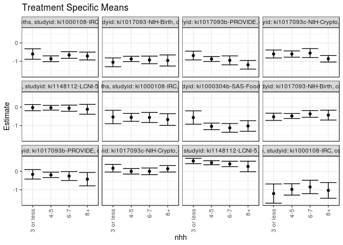

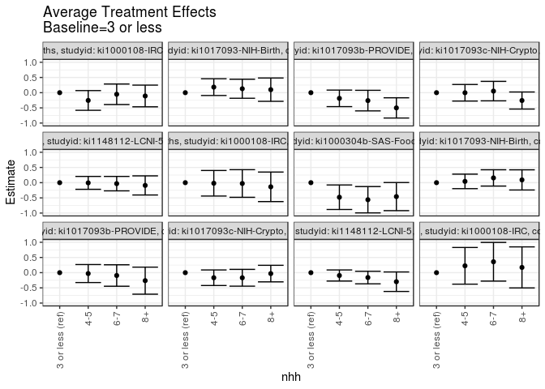

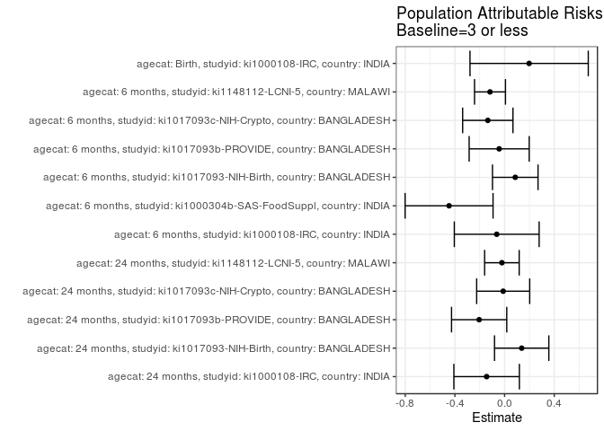

## Results Table

### Parameter: TSM

| agecat | studyid | country | intervention_level | baseline_level | estimate | ci_lower | ci_upper |
| --- | --- | --- | --- | --- | --- | --- | --- |
| Birth | ki1000108-IRC | INDIA | 3 or less | NA | -1.2083669 | -1.7295554 | -0.6871785 |
| Birth | ki1000108-IRC | INDIA | 4-5 | NA | -0.9833949 | -1.2919000 | -0.6748898 |
| Birth | ki1000108-IRC | INDIA | 6-7 | NA | -0.8497628 | -1.2124112 | -0.4871143 |
| Birth | ki1000108-IRC | INDIA | 8+ | NA | -1.0359715 | -1.4622657 | -0.6096774 |
| 6 months | ki1000108-IRC | INDIA | 3 or less | NA | -0.5357196 | -0.8991976 | -0.1722416 |
| 6 months | ki1000108-IRC | INDIA | 4-5 | NA | -0.5553731 | -0.7680618 | -0.3426843 |
| 6 months | ki1000108-IRC | INDIA | 6-7 | NA | -0.5627437 | -0.8360617 | -0.2894257 |
| 6 months | ki1000108-IRC | INDIA | 8+ | NA | -0.6723126 | -0.9893095 | -0.3553157 |
| 6 months | ki1000304b-SAS-FoodSuppl | INDIA | 3 or less | NA | -0.5652545 | -0.9264149 | -0.2040941 |
| 6 months | ki1000304b-SAS-FoodSuppl | INDIA | 4-5 | NA | -1.0445019 | -1.2213448 | -0.8676589 |
| 6 months | ki1000304b-SAS-FoodSuppl | INDIA | 6-7 | NA | -1.1261964 | -1.3636967 | -0.8886961 |
| 6 months | ki1000304b-SAS-FoodSuppl | INDIA | 8+ | NA | -1.0229847 | -1.3106963 | -0.7352732 |
| 6 months | ki1017093-NIH-Birth | BANGLADESH | 3 or less | NA | -0.5249194 | -0.7218856 | -0.3279531 |
| 6 months | ki1017093-NIH-Birth | BANGLADESH | 4-5 | NA | -0.4825988 | -0.6188741 | -0.3463235 |
| 6 months | ki1017093-NIH-Birth | BANGLADESH | 6-7 | NA | -0.3684197 | -0.5521132 | -0.1847262 |
| 6 months | ki1017093-NIH-Birth | BANGLADESH | 8+ | NA | -0.4336485 | -0.7013727 | -0.1659243 |
| 6 months | ki1017093b-PROVIDE | BANGLADESH | 3 or less | NA | -0.1649081 | -0.4222098 | 0.0923935 |
| 6 months | ki1017093b-PROVIDE | BANGLADESH | 4-5 | NA | -0.1937077 | -0.3394458 | -0.0479697 |
| 6 months | ki1017093b-PROVIDE | BANGLADESH | 6-7 | NA | -0.2584774 | -0.4996068 | -0.0173480 |
| 6 months | ki1017093b-PROVIDE | BANGLADESH | 8+ | NA | -0.4276089 | -0.7911394 | -0.0640784 |
| 6 months | ki1017093c-NIH-Crypto | BANGLADESH | 3 or less | NA | 0.1648042 | -0.0432928 | 0.3729012 |
| 6 months | ki1017093c-NIH-Crypto | BANGLADESH | 4-5 | NA | -0.0019662 | -0.1515454 | 0.1476130 |
| 6 months | ki1017093c-NIH-Crypto | BANGLADESH | 6-7 | NA | -0.0034328 | -0.1846765 | 0.1778109 |
| 6 months | ki1017093c-NIH-Crypto | BANGLADESH | 8+ | NA | 0.1348915 | -0.0409746 | 0.3107576 |
| 6 months | ki1148112-LCNI-5 | MALAWI | 3 or less | NA | 0.5591348 | 0.4135514 | 0.7047183 |
| 6 months | ki1148112-LCNI-5 | MALAWI | 4-5 | NA | 0.4657509 | 0.3561097 | 0.5753920 |
| 6 months | ki1148112-LCNI-5 | MALAWI | 6-7 | NA | 0.3992284 | 0.2522234 | 0.5462334 |
| 6 months | ki1148112-LCNI-5 | MALAWI | 8+ | NA | 0.2616611 | -0.0244659 | 0.5477880 |
| 24 months | ki1000108-IRC | INDIA | 3 or less | NA | -0.6012791 | -0.8859242 | -0.3166341 |
| 24 months | ki1000108-IRC | INDIA | 4-5 | NA | -0.8565385 | -1.0124268 | -0.7006502 |
| 24 months | ki1000108-IRC | INDIA | 6-7 | NA | -0.6542829 | -0.8348069 | -0.4737590 |
| 24 months | ki1000108-IRC | INDIA | 8+ | NA | -0.7100863 | -0.9222661 | -0.4979065 |
| 24 months | ki1017093-NIH-Birth | BANGLADESH | 3 or less | NA | -1.0493263 | -1.2883900 | -0.8102626 |
| 24 months | ki1017093-NIH-Birth | BANGLADESH | 4-5 | NA | -0.8667054 | -1.0097701 | -0.7236407 |
| 24 months | ki1017093-NIH-Birth | BANGLADESH | 6-7 | NA | -0.9198314 | -1.1262010 | -0.7134618 |
| 24 months | ki1017093-NIH-Birth | BANGLADESH | 8+ | NA | -0.9507391 | -1.2524571 | -0.6490211 |
| 24 months | ki1017093b-PROVIDE | BANGLADESH | 3 or less | NA | -0.6832480 | -0.9211685 | -0.4453275 |
| 24 months | ki1017093b-PROVIDE | BANGLADESH | 4-5 | NA | -0.8699295 | -1.0056423 | -0.7342167 |
| 24 months | ki1017093b-PROVIDE | BANGLADESH | 6-7 | NA | -0.9439108 | -1.1864804 | -0.7013413 |
| 24 months | ki1017093b-PROVIDE | BANGLADESH | 8+ | NA | -1.1843746 | -1.4196653 | -0.9490840 |
| 24 months | ki1017093c-NIH-Crypto | BANGLADESH | 3 or less | NA | -0.5991798 | -0.8137690 | -0.3845907 |
| 24 months | ki1017093c-NIH-Crypto | BANGLADESH | 4-5 | NA | -0.6018081 | -0.7715640 | -0.4320522 |
| 24 months | ki1017093c-NIH-Crypto | BANGLADESH | 6-7 | NA | -0.5477930 | -0.7884649 | -0.3071210 |
| 24 months | ki1017093c-NIH-Crypto | BANGLADESH | 8+ | NA | -0.8569172 | -1.0366534 | -0.6771810 |
| 24 months | ki1148112-LCNI-5 | MALAWI | 3 or less | NA | -0.0263754 | -0.1944374 | 0.1416866 |
| 24 months | ki1148112-LCNI-5 | MALAWI | 4-5 | NA | -0.0327595 | -0.1609418 | 0.0954229 |
| 24 months | ki1148112-LCNI-5 | MALAWI | 6-7 | NA | -0.0582584 | -0.2256445 | 0.1091277 |
| 24 months | ki1148112-LCNI-5 | MALAWI | 8+ | NA | -0.1168768 | -0.3835954 | 0.1498417 |

### Parameter: E(Y)

| agecat | studyid | country | intervention_level | baseline_level | estimate | ci_lower | ci_upper |
| --- | --- | --- | --- | --- | --- | --- | --- |
| Birth | ki1000108-IRC | INDIA | NA | NA | -1.0105831 | -1.1973019 | -0.8238643 |
| 6 months | ki1000108-IRC | INDIA | NA | NA | -0.5989297 | -0.7344491 | -0.4634104 |
| 6 months | ki1000304b-SAS-FoodSuppl | INDIA | NA | NA | -1.0121579 | -1.1280429 | -0.8962729 |
| 6 months | ki1017093-NIH-Birth | BANGLADESH | NA | NA | -0.4389101 | -0.5279432 | -0.3498771 |
| 6 months | ki1017093b-PROVIDE | BANGLADESH | NA | NA | -0.2083706 | -0.2927992 | -0.1239419 |
| 6 months | ki1017093c-NIH-Crypto | BANGLADESH | NA | NA | 0.0297622 | -0.0491685 | 0.1086930 |
| 6 months | ki1148112-LCNI-5 | MALAWI | NA | NA | 0.4418137 | 0.3703100 | 0.5133174 |
| 24 months | ki1000108-IRC | INDIA | NA | NA | -0.7458150 | -0.8368180 | -0.6548120 |
| 24 months | ki1017093-NIH-Birth | BANGLADESH | NA | NA | -0.9115790 | -1.0095022 | -0.8136559 |
| 24 months | ki1017093b-PROVIDE | BANGLADESH | NA | NA | -0.8879412 | -0.9708680 | -0.8050144 |
| 24 months | ki1017093c-NIH-Crypto | BANGLADESH | NA | NA | -0.6103502 | -0.7050157 | -0.5156847 |
| 24 months | ki1148112-LCNI-5 | MALAWI | NA | NA | -0.0478674 | -0.1301904 | 0.0344557 |

### Parameter: ATE

| agecat | studyid | country | intervention_level | baseline_level | estimate | ci_lower | ci_upper |
| --- | --- | --- | --- | --- | --- | --- | --- |
| Birth | ki1000108-IRC | INDIA | 3 or less | 3 or less | 0.0000000 | 0.0000000 | 0.0000000 |
| Birth | ki1000108-IRC | INDIA | 4-5 | 3 or less | 0.2249720 | -0.3783725 | 0.8283165 |
| Birth | ki1000108-IRC | INDIA | 6-7 | 3 or less | 0.3586042 | -0.2775605 | 0.9947688 |
| Birth | ki1000108-IRC | INDIA | 8+ | 3 or less | 0.1723954 | -0.5030430 | 0.8478338 |
| 6 months | ki1000108-IRC | INDIA | 3 or less | 3 or less | 0.0000000 | 0.0000000 | 0.0000000 |
| 6 months | ki1000108-IRC | INDIA | 4-5 | 3 or less | -0.0196535 | -0.4404984 | 0.4011915 |
| 6 months | ki1000108-IRC | INDIA | 6-7 | 3 or less | -0.0270241 | -0.4818314 | 0.4277832 |
| 6 months | ki1000108-IRC | INDIA | 8+ | 3 or less | -0.1365930 | -0.6221717 | 0.3489857 |
| 6 months | ki1000304b-SAS-FoodSuppl | INDIA | 3 or less | 3 or less | 0.0000000 | 0.0000000 | 0.0000000 |
| 6 months | ki1000304b-SAS-FoodSuppl | INDIA | 4-5 | 3 or less | -0.4792473 | -0.8830532 | -0.0754415 |
| 6 months | ki1000304b-SAS-FoodSuppl | INDIA | 6-7 | 3 or less | -0.5609419 | -0.9940744 | -0.1278094 |
| 6 months | ki1000304b-SAS-FoodSuppl | INDIA | 8+ | 3 or less | -0.4577302 | -0.9204883 | 0.0050279 |
| 6 months | ki1017093-NIH-Birth | BANGLADESH | 3 or less | 3 or less | 0.0000000 | 0.0000000 | 0.0000000 |
| 6 months | ki1017093-NIH-Birth | BANGLADESH | 4-5 | 3 or less | 0.0423206 | -0.1964228 | 0.2810640 |
| 6 months | ki1017093-NIH-Birth | BANGLADESH | 6-7 | 3 or less | 0.1564997 | -0.1118625 | 0.4248619 |
| 6 months | ki1017093-NIH-Birth | BANGLADESH | 8+ | 3 or less | 0.0912709 | -0.2404398 | 0.4229815 |
| 6 months | ki1017093b-PROVIDE | BANGLADESH | 3 or less | 3 or less | 0.0000000 | 0.0000000 | 0.0000000 |
| 6 months | ki1017093b-PROVIDE | BANGLADESH | 4-5 | 3 or less | -0.0287996 | -0.3246417 | 0.2670425 |
| 6 months | ki1017093b-PROVIDE | BANGLADESH | 6-7 | 3 or less | -0.0935693 | -0.4462909 | 0.2591524 |
| 6 months | ki1017093b-PROVIDE | BANGLADESH | 8+ | 3 or less | -0.2627007 | -0.7076439 | 0.1822424 |
| 6 months | ki1017093c-NIH-Crypto | BANGLADESH | 3 or less | 3 or less | 0.0000000 | 0.0000000 | 0.0000000 |
| 6 months | ki1017093c-NIH-Crypto | BANGLADESH | 4-5 | 3 or less | -0.1667704 | -0.4231311 | 0.0895903 |
| 6 months | ki1017093c-NIH-Crypto | BANGLADESH | 6-7 | 3 or less | -0.1682370 | -0.4443155 | 0.1078415 |
| 6 months | ki1017093c-NIH-Crypto | BANGLADESH | 8+ | 3 or less | -0.0299127 | -0.3024816 | 0.2426561 |
| 6 months | ki1148112-LCNI-5 | MALAWI | 3 or less | 3 or less | 0.0000000 | 0.0000000 | 0.0000000 |
| 6 months | ki1148112-LCNI-5 | MALAWI | 4-5 | 3 or less | -0.0933839 | -0.2756660 | 0.0888982 |
| 6 months | ki1148112-LCNI-5 | MALAWI | 6-7 | 3 or less | -0.1599064 | -0.3669043 | 0.0470915 |
| 6 months | ki1148112-LCNI-5 | MALAWI | 8+ | 3 or less | -0.2974738 | -0.6184217 | 0.0234742 |
| 24 months | ki1000108-IRC | INDIA | 3 or less | 3 or less | 0.0000000 | 0.0000000 | 0.0000000 |
| 24 months | ki1000108-IRC | INDIA | 4-5 | 3 or less | -0.2552594 | -0.5797485 | 0.0692297 |
| 24 months | ki1000108-IRC | INDIA | 6-7 | 3 or less | -0.0530038 | -0.3908489 | 0.2848413 |
| 24 months | ki1000108-IRC | INDIA | 8+ | 3 or less | -0.1088071 | -0.4654841 | 0.2478698 |
| 24 months | ki1017093-NIH-Birth | BANGLADESH | 3 or less | 3 or less | 0.0000000 | 0.0000000 | 0.0000000 |
| 24 months | ki1017093-NIH-Birth | BANGLADESH | 4-5 | 3 or less | 0.1826209 | -0.0925160 | 0.4577577 |
| 24 months | ki1017093-NIH-Birth | BANGLADESH | 6-7 | 3 or less | 0.1294948 | -0.1841210 | 0.4431107 |
| 24 months | ki1017093-NIH-Birth | BANGLADESH | 8+ | 3 or less | 0.0985872 | -0.2853450 | 0.4825193 |
| 24 months | ki1017093b-PROVIDE | BANGLADESH | 3 or less | 3 or less | 0.0000000 | 0.0000000 | 0.0000000 |
| 24 months | ki1017093b-PROVIDE | BANGLADESH | 4-5 | 3 or less | -0.1866815 | -0.4586312 | 0.0852681 |
| 24 months | ki1017093b-PROVIDE | BANGLADESH | 6-7 | 3 or less | -0.2606629 | -0.5989634 | 0.0776376 |
| 24 months | ki1017093b-PROVIDE | BANGLADESH | 8+ | 3 or less | -0.5011266 | -0.8339462 | -0.1683070 |
| 24 months | ki1017093c-NIH-Crypto | BANGLADESH | 3 or less | 3 or less | 0.0000000 | 0.0000000 | 0.0000000 |
| 24 months | ki1017093c-NIH-Crypto | BANGLADESH | 4-5 | 3 or less | -0.0026282 | -0.2753570 | 0.2701006 |
| 24 months | ki1017093c-NIH-Crypto | BANGLADESH | 6-7 | 3 or less | 0.0513869 | -0.2691539 | 0.3719277 |
| 24 months | ki1017093c-NIH-Crypto | BANGLADESH | 8+ | 3 or less | -0.2577373 | -0.5385958 | 0.0231212 |
| 24 months | ki1148112-LCNI-5 | MALAWI | 3 or less | 3 or less | 0.0000000 | 0.0000000 | 0.0000000 |
| 24 months | ki1148112-LCNI-5 | MALAWI | 4-5 | 3 or less | -0.0063841 | -0.2184902 | 0.2057220 |
| 24 months | ki1148112-LCNI-5 | MALAWI | 6-7 | 3 or less | -0.0318830 | -0.2694694 | 0.2057034 |
| 24 months | ki1148112-LCNI-5 | MALAWI | 8+ | 3 or less | -0.0905015 | -0.4052105 | 0.2242076 |

### Parameter: PAR

| agecat | studyid | country | intervention_level | baseline_level | estimate | ci_lower | ci_upper |
| --- | --- | --- | --- | --- | --- | --- | --- |
| Birth | ki1000108-IRC | INDIA | 3 or less | NA | 0.1977839 | -0.2784471 | 0.6740149 |
| 6 months | ki1000108-IRC | INDIA | 3 or less | NA | -0.0632101 | -0.4047494 | 0.2783292 |
| 6 months | ki1000304b-SAS-FoodSuppl | INDIA | 3 or less | NA | -0.4469034 | -0.8009300 | -0.0928768 |
| 6 months | ki1017093-NIH-Birth | BANGLADESH | 3 or less | NA | 0.0860092 | -0.0974108 | 0.2694293 |
| 6 months | ki1017093b-PROVIDE | BANGLADESH | 3 or less | NA | -0.0434624 | -0.2852379 | 0.1983131 |
| 6 months | ki1017093c-NIH-Crypto | BANGLADESH | 3 or less | NA | -0.1350420 | -0.3375889 | 0.0675049 |
| 6 months | ki1148112-LCNI-5 | MALAWI | 3 or less | NA | -0.1173211 | -0.2419226 | 0.0072804 |
| 24 months | ki1000108-IRC | INDIA | 3 or less | NA | -0.1445359 | -0.4082568 | 0.1191851 |
| 24 months | ki1017093-NIH-Birth | BANGLADESH | 3 or less | NA | 0.1377472 | -0.0809478 | 0.3564422 |
| 24 months | ki1017093b-PROVIDE | BANGLADESH | 3 or less | NA | -0.2046932 | -0.4270413 | 0.0176549 |
| 24 months | ki1017093c-NIH-Crypto | BANGLADESH | 3 or less | NA | -0.0111703 | -0.2247300 | 0.2023893 |
| 24 months | ki1148112-LCNI-5 | MALAWI | 3 or less | NA | -0.0214920 | -0.1606654 | 0.1176814 |